# How Well Did Indonesia Handle Covid-19 Compared to Other Countries?

### A CMSC320 Data Science Pipeline Tutorial

## Contents

- Introduction
- Setup
- Exploratory Data Analysis
- Hypothesis Testing: Standardization
- Analysis cont'd
- Conclusion

## Introduction

This tutorial is aimed at walking readers through the steps of the standard data science pipeline, which includes data collection/curation and parsing, data management/representation, exploratory data analysis, hypothesis testing and/or machine learning, and communication of insights attained.

Indonesia is one of the most populated, developing countries in the world. It is located in South-East Asia with a population of nearly 300 million people. Since the beginning of 2020 when the pandemic first started, Indonesia has been criticized for their inefficient pandemic measures. On the other hand, others argue that Indonesia has done a successful job at handling the spread of the virus. Neighbored by countries such as Australia, Singapore, and Vietnam which are known for their success stories, as well as many others with their not-so-successful stories, how well did Indonesia handle covid-19 compared to other countries?

In other words, we will look at the infection data, deaths, and vaccination rates of Indonesia with other contributing variables, compared to other countries.

Click here for more information on Indonesia's efforts and response to the pandemic:

- https://indonesien.ahk.de/en/infocenter/news/news-details/covid-19-developments-in-indonesia
- https://home.kpmg/xx/en/home/insights/2020/04/indonesia-government-and-institution-measures-in-response-to-covid.html

and here for more information on which countries rank the best and worst based on their covid handling:

- https://www.movehub.com/blog/best-and-worst-covid-responses/

## Setup

We first import the necessary libraries to gather and process the data.

- Matplotlib.pyplot: creates plots
- Seaborn: creates plots
- Pandas: organize data in dataframes
- Numpy: math and array functions
- Datetime: convert string to datetime
- Warnings: suppress python warnings

```python
import matplotlib.pyplot as plt
import pandas as pd
import numpy as np
import datetime
import seaborn as sns
import warnings
warnings.filterwarnings('ignore')
```

We will gather our data from "Our World in Data", which contains daily updated data on covid-19 all around the world. The complete dataset is available on github and in csv, xlsx, and json, here:

- https://github.com/owid/covid-19-data/tree/master/public/data

The data consists of:

- [confirmed cases and deaths from the John Hopkins University](https://github.com/CSSEGISandData/COVID-19)
- [hospitalizations and intensive care unit admissions from the ECDC](https://www.ecdc.europa.eu/en/publications-data/download-data-hospital-and-icu-admission-rates-and-current-occupancy-covid-19)
- [testing for covid-19](https://ourworldindata.org/coronavirus-testing#our-checklist-for-covid-19-testing-data)
- vaccinations against covid-19
- other variables

Since the data is available in one csv document, we load the data from the webpage into a temporary dataframe. We store the data into a -- later -- untouched dataframe this since the file is large and takes a long time to read.

```python
# Read csv file from url and save it initially to an untouched dataframe since file is large.
initial_df = pd.read_csv("https://covid.ourworldindata.org/data/owid-covid-data.csv")

initial_df
```

|  | iso_code | continent | location | date | total_cases | new_cases | new_cases_smoothed | total_deaths | new_deaths | new_deaths_smoothed | ... | gdp_per_capita | extreme_poverty | cardiovasc_death_rate | diabetes_prevalence | female_smokers | male_smokers | handwashing_facilities | hospital_beds_per_thousand | life_expectancy | human_development_index |
| --- | --- | --- | --- | --- | --- | --- | --- | --- | --- | --- | --- | --- | --- | --- | --- | --- | --- | --- | --- | --- | --- |
| 0 | AFG | Asia | Afghanistan | 2020-02-24 | 1.0 | 1.0 | NaN | NaN | NaN | NaN | ... | 1803.987 | NaN | 597.029 | 9.59 | NaN | NaN | 37.746 | 0.5 | 64.83 | 0.511 |
| 1 | AFG | Asia | Afghanistan | 2020-02-25 | 1.0 | 0.0 | NaN | NaN | NaN | NaN | ... | 1803.987 | NaN | 597.029 | 9.59 | NaN | NaN | 37.746 | 0.5 | 64.83 | 0.511 |
| 2 | AFG | Asia | Afghanistan | 2020-02-26 | 1.0 | 0.0 | NaN | NaN | NaN | NaN | ... | 1803.987 | NaN | 597.029 | 9.59 | NaN | NaN | 37.746 | 0.5 | 64.83 | 0.511 |
| 3 | AFG | Asia | Afghanistan | 2020-02-27 | 1.0 | 0.0 | NaN | NaN | NaN | NaN | ... | 1803.987 | NaN | 597.029 | 9.59 | NaN | NaN | 37.746 | 0.5 | 64.83 | 0.511 |
| 4 | AFG | Asia | Afghanistan | 2020-02-28 | 1.0 | 0.0 | NaN | NaN | NaN | NaN | ... | 1803.987 | NaN | 597.029 | 9.59 | NaN | NaN | 37.746 | 0.5 | 64.83 | 0.511 |
| ... | ... | ... | ... | ... | ... | ... | ... | ... | ... | ... | ... | ... | ... | ... | ... | ... | ... | ... | ... | ... | ... |
| 89138 | ZWE | Africa | Zimbabwe | 2021-05-12 | 38466.0 | 18.0 | 15.571 | 1579.0 | 0.0 | 0.714 | ... | 1899.775 | 21.4 | 307.846 | 1.82 | 1.6 | 30.7 | 36.791 | 1.7 | 61.49 | 0.571 |
| 89139 | ZWE | Africa | Zimbabwe | 2021-05-13 | 38491.0 | 25.0 | 13.286 | 1582.0 | 3.0 | 1.000 | ... | 1899.775 | 21.4 | 307.846 | 1.82 | 1.6 | 30.7 | 36.791 | 1.7 | 61.49 | 0.571 |
| 89140 | ZWE | Africa | Zimbabwe | 2021-05-14 | 38535.0 | 44.0 | 18.857 | 1582.0 | 0.0 | 0.857 | ... | 1899.775 | 21.4 | 307.846 | 1.82 | 1.6 | 30.7 | 36.791 | 1.7 | 61.49 | 0.571 |
| 89141 | ZWE | Africa | Zimbabwe | 2021-05-15 | 38554.0 | 19.0 | 20.000 | 1582.0 | 0.0 | 0.857 | ... | 1899.775 | 21.4 | 307.846 | 1.82 | 1.6 | 30.7 | 36.791 | 1.7 | 61.49 | 0.571 |
| 89142 | ZWE | Africa | Zimbabwe | 2021-05-16 | 38560.0 | 6.0 | 20.143 | 1582.0 | 0.0 | 0.857 | ... | 1899.775 | 21.4 | 307.846 | 1.82 | 1.6 | 30.7 | 36.791 | 1.7 | 61.49 | 0.571 |

89143 rows × 59 columns

## Data Management/Representation

We first get the necessary attributes from the initial dataframe and change to the timestamp format for 'date' to make it easier to plot later on. We also add 'quarter', 'month', and 'fatality_rate' based on the given attributes, and drop 'nan' continents, since the dataset also includes tuples for a 'World' continent, containing the aggregate data of all countries' attributes.

Learn more about Pandas dataframes [here](https://www.google.com/search?client=safari&rls=en&q=pandas+dataframe+formatting&ie=UTF-8&oe=UTF-8).

```python
# Grab only the necessary columns for data analysis.
df = initial_df[["continent","location","date","total_cases","total_deaths","people_fully_vaccinated","population"]]

# Convert date from string to timestamp object.
df['date'] = pd.to_datetime(df['date'])
df['date'] = df['date'].dt.date

# Add new columns.
df['quarter'] = pd.PeriodIndex(pd.to_datetime(initial_df['date']), freq='Q')
df['month'] = pd.to_datetime(initial_df['date']).dt.to_period('M')
df['fatality_rate'] = df['total_deaths'] / df['total_cases']

# Drop nan continents; rows containing nan continents contain world's total values instead of each country's.
df = df[df['continent'].notna()]
df = df[['continent','location','date','quarter','month','fatality_rate','total_cases','total_deaths','people_fully_vaccinated','population']]
df
```

|  | continent | location | date | quarter | month | fatality_rate | total_cases | total_deaths | people_fully_vaccinated | population |
| --- | --- | --- | --- | --- | --- | --- | --- | --- | --- | --- |
| 0 | Asia | Afghanistan | 2020-02-24 | 2020Q1 | 2020-02 | NaN | 1.0 | NaN | NaN | 38928341.0 |
| 1 | Asia | Afghanistan | 2020-02-25 | 2020Q1 | 2020-02 | NaN | 1.0 | NaN | NaN | 38928341.0 |
| 2 | Asia | Afghanistan | 2020-02-26 | 2020Q1 | 2020-02 | NaN | 1.0 | NaN | NaN | 38928341.0 |
| 3 | Asia | Afghanistan | 2020-02-27 | 2020Q1 | 2020-02 | NaN | 1.0 | NaN | NaN | 38928341.0 |
| 4 | Asia | Afghanistan | 2020-02-28 | 2020Q1 | 2020-02 | NaN | 1.0 | NaN | NaN | 38928341.0 |
| ... | ... | ... | ... | ... | ... | ... | ... | ... | ... | ... |
| 89138 | Africa | Zimbabwe | 2021-05-12 | 2021Q2 | 2021-05 | 0.041049 | 38466.0 | 1579.0 | 180568.0 | 14862927.0 |
| 89139 | Africa | Zimbabwe | 2021-05-13 | 2021Q2 | 2021-05 | 0.041101 | 38491.0 | 1582.0 | 192145.0 | 14862927.0 |
| 89140 | Africa | Zimbabwe | 2021-05-14 | 2021Q2 | 2021-05 | 0.041054 | 38535.0 | 1582.0 | 203781.0 | 14862927.0 |
| 89141 | Africa | Zimbabwe | 2021-05-15 | 2021Q2 | 2021-05 | 0.041033 | 38554.0 | 1582.0 | 213542.0 | 14862927.0 |
| 89142 | Africa | Zimbabwe | 2021-05-16 | 2021Q2 | 2021-05 | 0.041027 | 38560.0 | 1582.0 | 215332.0 | 14862927.0 |

84888 rows × 10 columns

Now, we get the necessary columns from the dataframe and add some new attributes. This includes:

- continent: A country's continent.
- location: Country name.
- date: date during which data was recorded.
- quarter: year-quarter of during which data was recorded.
- month: year-month of during which data was recorded.
- fatality_rate: total_deaths to total_cases ratio.
- total_cases: Total confirmed cases of covid-19.
- total_deaths: Total confirmed deaths of covid-19.
- people_fully_vaccinated: Total number of people who received all does prescribed by the vaccination.
- population: country's population.

## Exploratory Data Analysis

Next, we will start exploring our dataset by creating different charts to analyze Indonesia's and other countries' covid-19 attributes. We start by looking at the mean covid-19 cases of all countries per day. We do this by grouping up the data by date, finding the mean of the total cases, and then plot a 2d-line graph using matlab plt.

Learn more about matlab 2d-line plots [here](https://www.mathworks.com/help/matlab/creating_plots/using-high-level-plotting-functions.html?requestedDomain=).

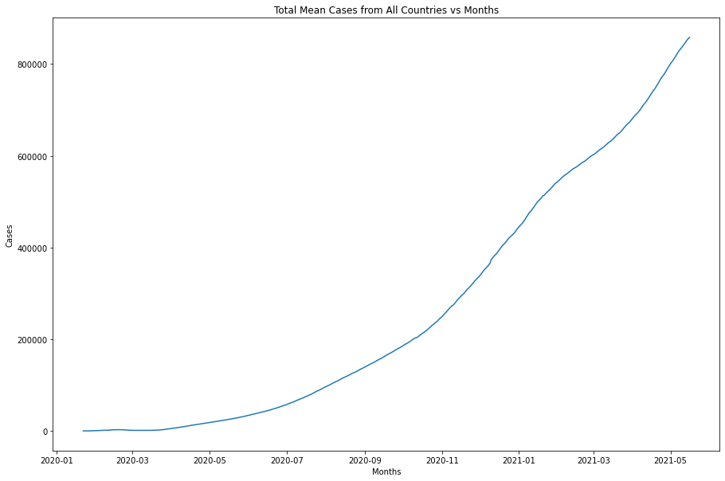

```python
# Display the mean of total_cases grouped by date. And set figure size.
df.groupby('date')['total_cases'].mean().plot(figsize=(15,10))

# Set title and axis labels
plt.title("Total Mean Cases from All Countries vs Months")
plt.xlabel("Months")
plt.ylabel("Cases")

# Show plot
plt.show()
```

The graph shows an increase in covid-19 infections all over the world, generally. However, this graph doesn't tell us how each country compares. We want to get a deeper look at how much covid-19 infections differ from country-to-country.

Therefore, we will go through each country's data and plot its total cases vs months. Each country will have its own line graph.

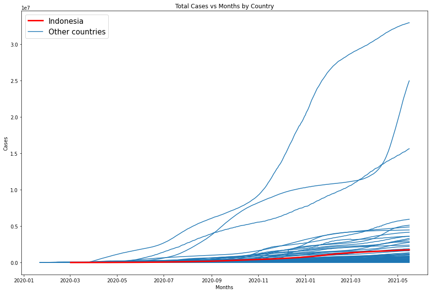

```python
# Create a copy dataframe containing tuples for Indonesia
df_indo = df[df.location == 'Indonesia']

# Set figure size, and title and axis labels.
plt.figure(figsize=(15,10))
plt.title("Total Cases vs Months by Country")
plt.xlabel("Months")
plt.ylabel("Cases")

# Go through tuples grouped by countries.
for loc, data in df.groupby('location'):
    # Plot each countrie's total_cases vs date. And set appropriate color and label.
    x = data.date
    y = data.total_cases
    if loc != 'Indonesia':
        # Save plot for label in legend.
        ax = plt.plot(x,y, color='#1f77b4',label='Other countries')

# Save plot for label in legend.
ax += plt.plot(df_indo.date,df_indo.total_cases,color='red',linewidth=3,label='Indonesia')

# Show legend and plot.
plt.legend(handles=[ax[1], ax[0]],loc = "upper left",prop={'size': 15})
plt.show()
```

Now we can see where Indonesia lies compared to other countries, in terms of total cases vs date. It looks like Indonesia is somewhere in the middle. Based on the graph, Indonesia have had under 2.5 million covid-cases, while other countries have reached over 30 million cases. While this may initially look good, we don't know if this means that most people in the country are infected, or only a small part of the population are infected. So far, we only know that Indonesia isn't the worst, nor the best in total covid-19 infections/cases around the world.

However, countries vary by population, so we have to dive even deeper and see how its cases compare with its population.

Since the data is fairly large, we will isolate the data based on the dataset's 'quarter' attribute. The quarters are divided as such:

- Q1: January - March
- Q2: April - June
- Q3: July - September
- Q4: October - December

For each quarter, we will create a scatter plot showing each country's mean cases vs population. Moreover, each plot will have a linear regression showing the mean of case to population ratio for all countries. Therefore, we can see where Indonesia lies in relation with other countries, and deduce if Indonesia is above or under the mean case to population ratio. We will be able to get a better idea of the portion of the population that has been infected, and if Indonesia is higher or lower than the average infection rate.

I chose to use np.polyfit() to create the linear regression compared to SciKitLearn's LinearRegression() as I'm already used to this method. However, they both work exactly the same and is totally based on your preference. I suggest you to use any method that you're already used to.

Learn more about Numpy polyfit [here](https://blog.finxter.com/np-polyfit/), ScitKitLearn LinearRegression [here](https://stackabuse.com/linear-regression-in-python-with-scikit-learn/), and Pyplot scatter [here](https://www.tutorialspoint.com/matplotlib/matplotlib_scatter_plot.htm).

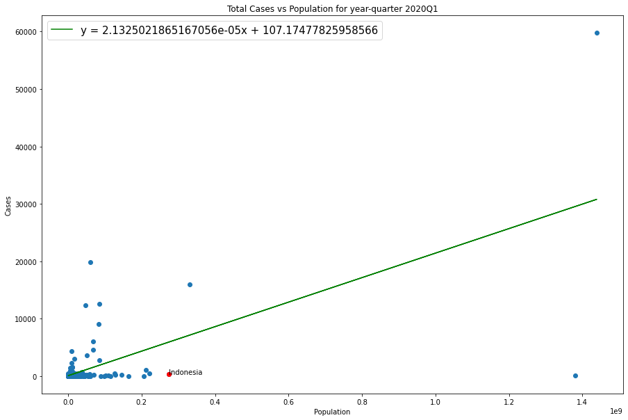

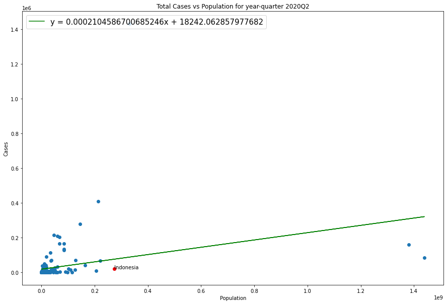

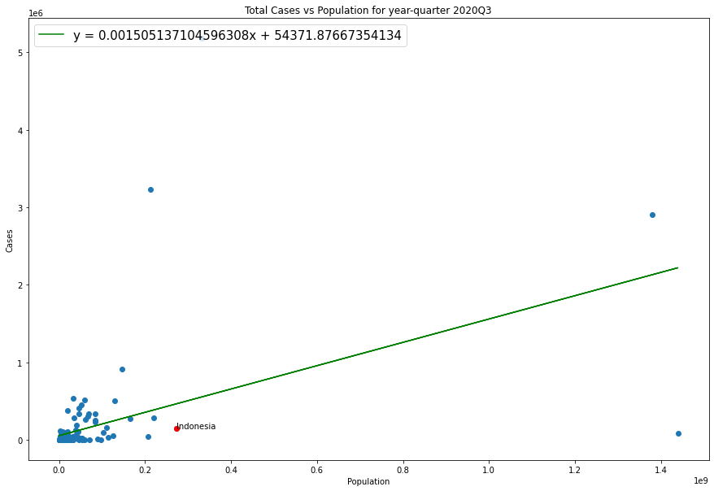

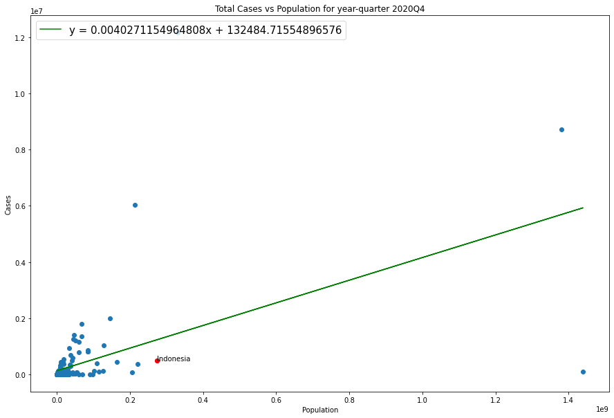

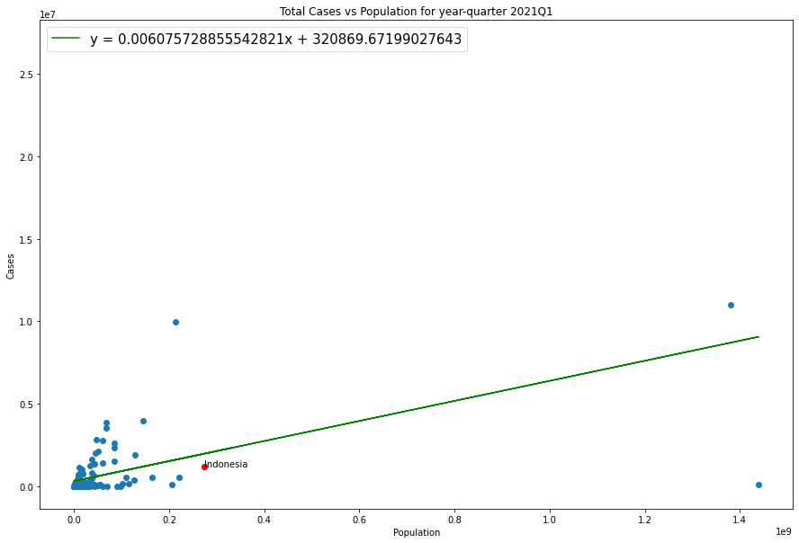

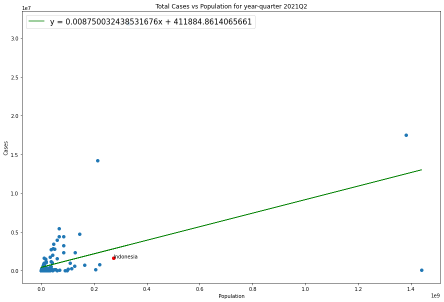

```python
# Go through tuples grouped by quarter.
for quarter, data in df.groupby('quarter'):

    # Set x and y values according to population mean grouped by country, and total_cases mean grouped by country
    # respectively.
    x = df.groupby(data.location).population.mean()
    y = df.groupby(data.location).total_cases.mean()

    # Set figure size, title, and axis labels.
    plt.figure(figsize=(15,10))
    plt.title("Total Cases vs Population for year-quarter " + str(quarter))
    plt.xlabel("Population")
    plt.ylabel("Cases")

    # Create scatter plots.
    plt.scatter(x,y)

    # Add text and red data point color to Indonesia.
    for i,v in x.items():
        if i == 'Indonesia':
            plt.text(v, y.get(i), i)
            plt.scatter(v, y.get(i), color="red")

    # Ignoring nan values, create linear regression for scatter plot.
    idx = np.isfinite(x) & np.isfinite(y)
    m, b = np.polyfit(x[idx], y[idx], 1)
    plt.plot(x, b + m * x, '-g', label = "y = " + str(m) + "x + " + str(b))

    # Show legend and plot.
    plt.legend(loc = "upper left",prop={'size': 15})
    plt.show()
```

Despite the increase in global covid-19 infections/cases, Indonesia have consistenly mantained below-average covid-19 cases. As seen in each quarter's graph, Indonesia is placed under the average case-to-population ratio. This means that Indonesia have maintained its population's covid-19 infection to be under the global average in all time periods. Based on global cases-to-population ratio, Indonesia have done very well in maintaing relatively low covid infection considering it is one of the most populated countries in the world.

Now we jump into the vaccination rate in the country. Using the same process, for each quarter, we will create a scatter plot showing each country's mean fully vaccinated individuals vs population. Moreover, each plot will have a linear regression showing the mean of vaccinated individuals ratio for all countries. Therefore, we can see where Indonesia lies in relation with other countries, and deduce if Indonesia is above or under the mean vaccinated individuals to population ratio. We will be able to get a better idea of the portion of the population that has been vaccinated, and see how much of Indonesia's population have been vaccinated, compared to other countries.

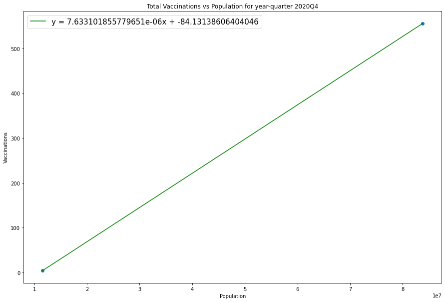

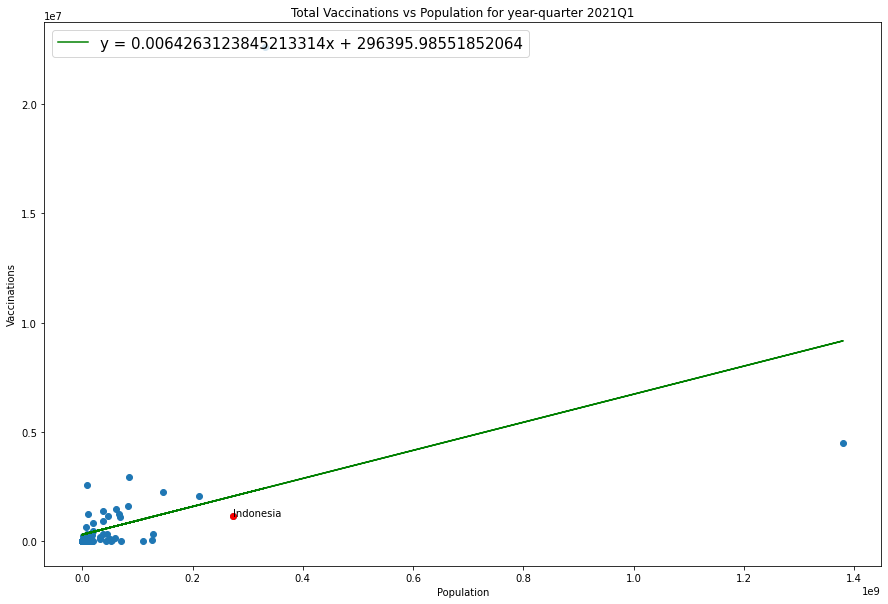

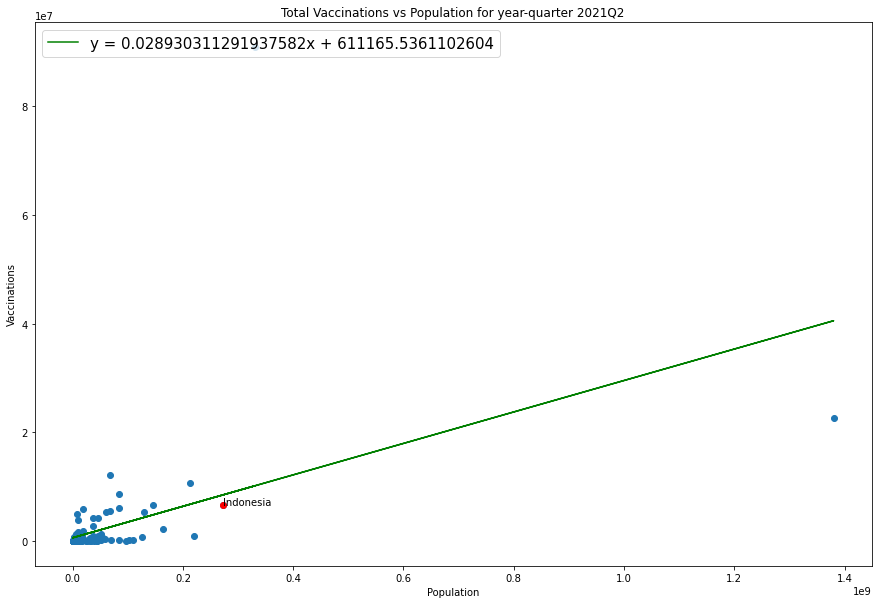

```python
# Create a copy dataframe containing tuples where people have been fully vaccinated.
df_vac = df[df.people_fully_vaccinated > 0]

# Go through tuples grouped by quarter.
for quarter, data in df_vac.groupby('quarter'):

    # Set x and y values as mean population grouped by country, and mean fully vaccinated individuals grouped by
    # location respectively.
    x = df_vac.groupby(data.location).population.mean()
    y = df_vac.groupby(data.location).people_fully_vaccinated.mean()

    # Set figure size, title, and axis labels.
    plt.figure(figsize=(15,10))
    plt.title("Total Vaccinations vs Population for year-quarter " + str(quarter))
    plt.xlabel("Population")
    plt.ylabel("Vaccinations")

    # Create scatter plot.
    plt.scatter(x,y)


    # Add text and red data point to Indonesia.
    for i,v in x.items():
        if i == 'Indonesia':
            plt.text(v, y.get(i), i)
            plt.scatter(v, y.get(i), color="red")

    # Ignoring nan values, create linear regression for scatter plot.
    idx = np.isfinite(x) & np.isfinite(y)
    m, b = np.polyfit(x[idx], y[idx], 1)
    plt.plot(x, b + m * x, '-g', label = "y = " + str(m) + "x + " + str(b))

    # Show legend and plot.
    plt.legend(loc = "upper left",prop={'size': 15})
    plt.show()
```

While Indonesia have maintained a positive record of having below-average covid-19 case-to-population ratio, Indonesia is still struggling to vaccinate the population. In comparison with other countries, Indonesia have below-average vaccination-to-population rate. This means that other countries' citizens are more likely to have been vaccinated than Indonesian citizens. Since Indonesia started its vaccination process in the first quarter of 2021, it has maintained below the global average for vaccinated individuals per population.

So far, Indonesia have done relatively well in preventing its citizens from covid-19 infections, but fall short of its vaccination rates compared to other countries.

Now we see how Indonesia handles its covid-19 patients, at reducing the country's fatality rates. Using the same process as before, for each quarter, we will create a scatter plot showing each country's recorded deaths vs cases. Moreover, each plot will have a linear regression showing the mean of fatality rate for all countries. Therefore, we can see where Indonesia lies in relation with other countries, and deduce if Indonesia has done well at handling covid-19 patients, and ultimately avoid/reduce fatalities. We will be able to get a better idea of the portion of the covid-19 cases that lead to death in Indonesia, compared to other countries.

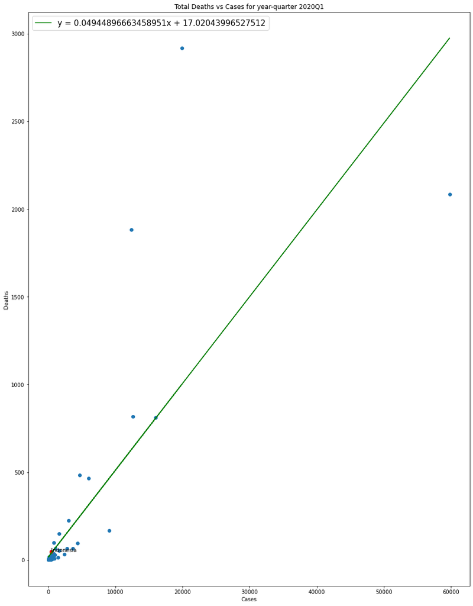

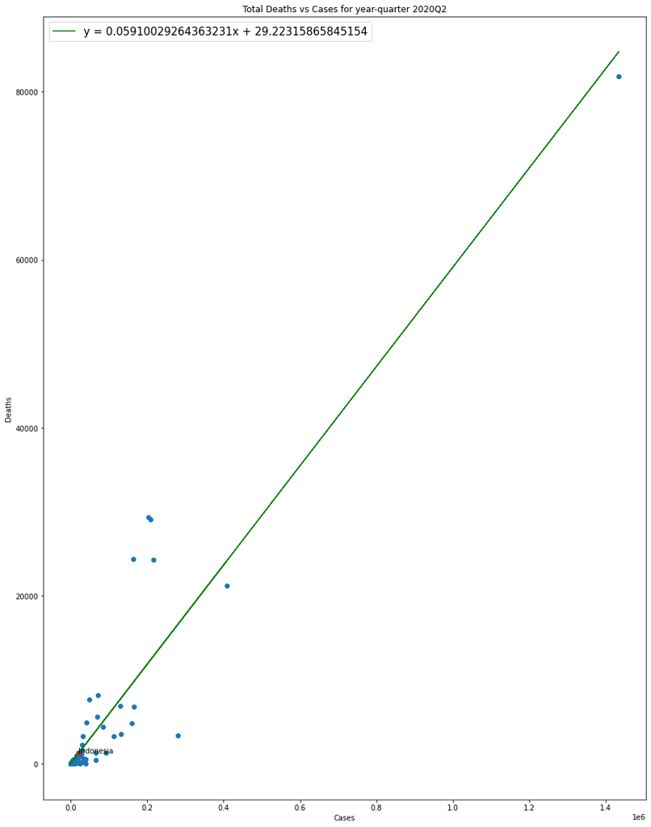

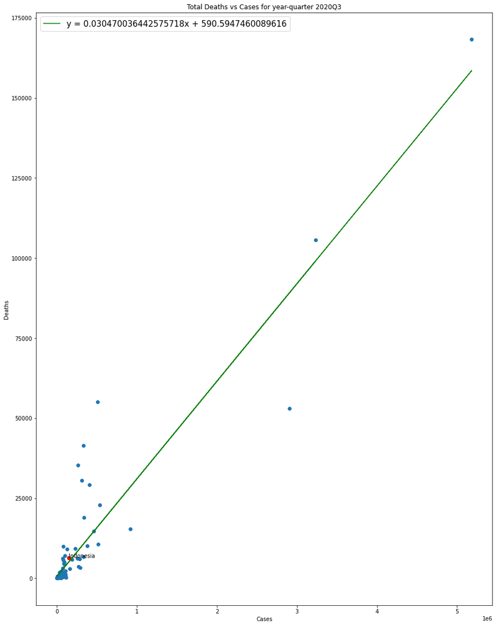

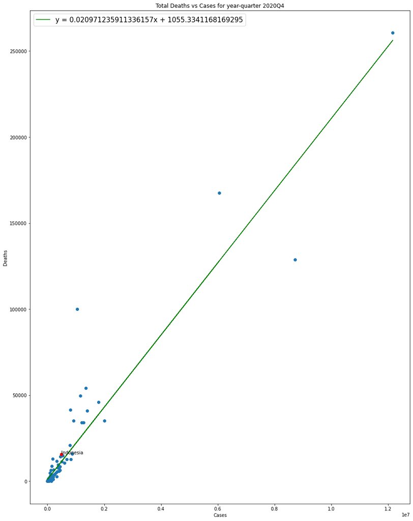

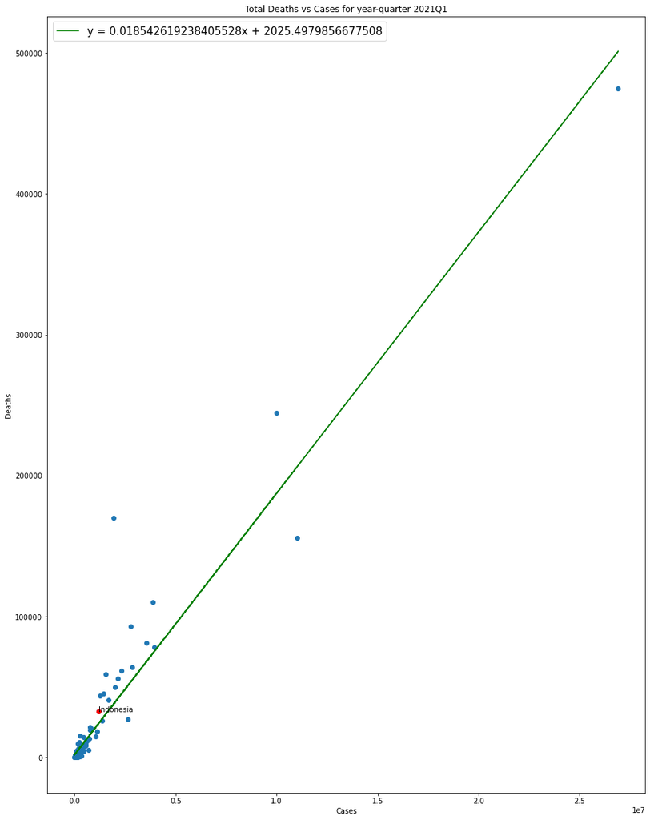

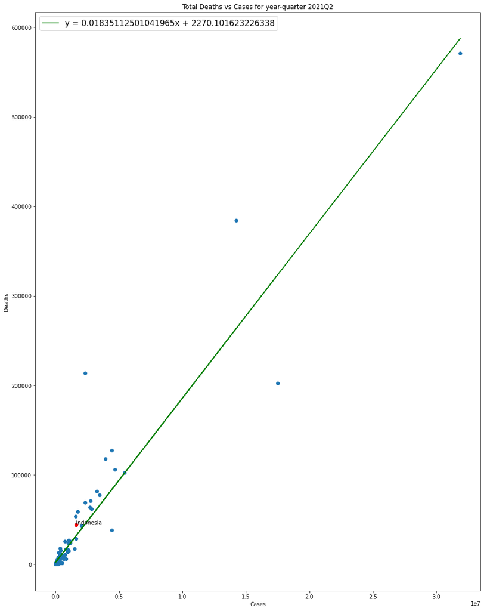

```python
# Go through tuples grouped by quarter.
for quarter, data in df.groupby('quarter'):
    # Set x and y values as mean total cases grouped by country, and mean deaths grouped by
    # location respectively.
    x = df.groupby(data.location).total_cases.mean()
    y = df.groupby(data.location).total_deaths.mean()

    # Set figure size, title, and axis labels.
    plt.figure(figsize=(15,20))
    plt.title("Total Deaths vs Cases for year-quarter " + str(quarter))
    plt.xlabel("Cases")
    plt.ylabel("Deaths")
    plt.scatter(x,y)

    # Add text and red data point to Indonesia.
    for i,v in x.items():
        if i == 'Indonesia':
            plt.text(v, y.get(i), i)
            plt.scatter(v, y.get(i), color="red")

    # Ignoring nan values, create linear regression for scatter plot.
    idx = np.isfinite(x) & np.isfinite(y)
    m, b = np.polyfit(x[idx], y[idx], 1)
    plt.plot(x, b + m * x, '-g', label = "y = " + str(m) + "x + " + str(b))

    # Show legend and plot.
    plt.legend(loc = "upper left",prop={'size': 15})
    plt.show()
```

In Q1 and Q2 of 2020, Indonesia's death-to-case ratio lies relatively average on a global scale. However, over time, Indonesia's death-to-case ratio have increased on the global average. This means that, covid-19 patients in Indonesia are more likely to result in a fatality compared to the global average. After Q2 of 2020, Indonesia have higher-than-average deaths per covid-19 case.

So far, we know that Indonesia has below-average covid-19 cases based on population. However, the country falls short in vaccination rates and high fatality rates among confirmed covid-19 cases, compared with the global average.

## Hypothesis Testing: Standardization

Now, we want to see how the fatality rates differ across different countries' populations. We know that Indonesia has below-average covid-19 cases based on population, but high fatality rates among confirmed covid-19 cases. We want to dive deeper into how these properties are related.

Learn more about Seaborn violinplot [here](https://stackabuse.com/seaborn-violin-plot-tutorial-and-examples/), standardized tests [here](https://www.statisticshowto.com/probability-and-statistics/hypothesis-testing/standardized-test-statistic/), and hypothesis testing [here](https://www.statisticshowto.com/probability-and-statistics/hypothesis-testing/).

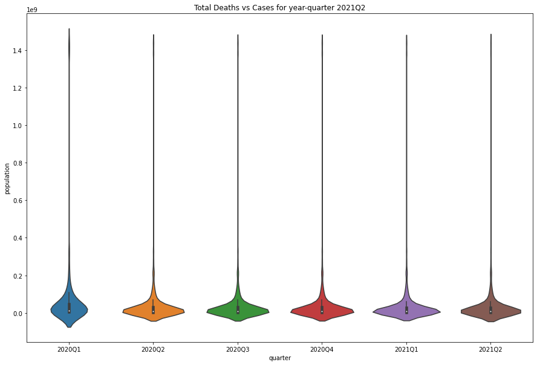

```python
# Set figure size, title, and axis labels.
plt.figure(figsize=(15,10))
plt.title("Total Deaths vs Cases for year-quarter " + str(quarter))
plt.xlabel("Cases")
plt.ylabel("Deaths")

# Create violinplot using seaborn. Set x and y data as quarter and population respectively.
ax = sns.violinplot(x=df.quarter, y=df.population)

# Show plot
plt.show()
```

We produced the violinplot, but the data is hard to read since they're quite zoomed out. We can zoom in into the larger areas of the violin to get a better look at the distribution by repeating the plot process and setting the range of the y-axis in the plot.

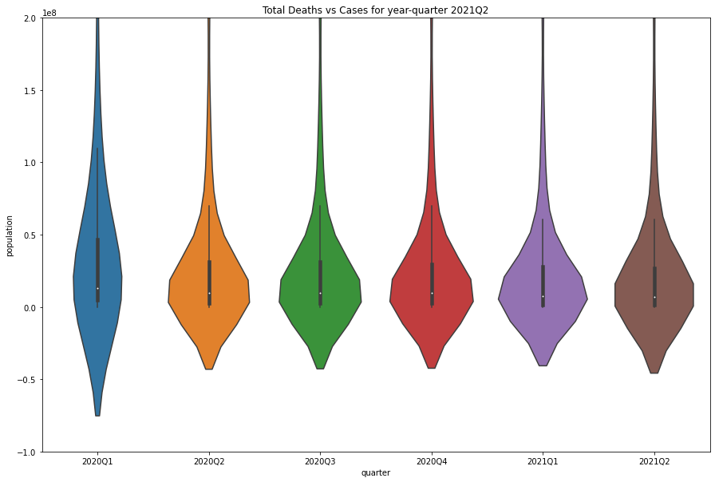

```python
# Same process as before.
plt.figure(figsize=(15,10))
plt.title("Total Deaths vs Cases for year-quarter " + str(quarter))
plt.xlabel("Cases")
plt.ylabel("Deaths")
ax = sns.violinplot(x=df.quarter, y=df.population)

# Zoom-in into violin plot.
ax.set(ylim=(-0.1 * 10 ** 9, 0.2 * 10 ** 9))

# Show plot.
plt.show()
```

Learn more about interpreting violin plots [here](https://mode.com/blog/violin-plot-examples/).

We start by creating a new column/attribute 'standardized_population' containing the initial population, then create the average population of all countries per month, and the standard deviation of population of all countries per month. For each entry in the new column, we follow this formula:

standardized_population =

((population of each country per day) - (average population of each country per month)) / (standard deviation of all country's population per month)

Learn more about Pandas aggregate functions [here](https://cmdlinetips.com/2019/10/pandas-groupby-13-functions-to-aggregate/).

```python
# Create new column standardized_population.
df['standardized_population'] = df.population

# Get population mean grouped by month.
avg_population = df.groupby('month').population.mean()

# Get population standard deviation grouped by month.
s = df.groupby('month').population.std()

# Go through tuples.
for index, row in df.iterrows():

    # Insert new standardized_population value.
    curr_avg_population = avg_population.get(row.month)
    curr_s = s.get(row.month)
    df.at[index,'standardized_population'] = (df.at[index, 'standardized_population'] - curr_avg_population) / curr_s

df
```

|  | continent | location | date | quarter | month | fatality_rate | total_cases | total_deaths | people_fully_vaccinated | population | standardized_population |
| --- | --- | --- | --- | --- | --- | --- | --- | --- | --- | --- | --- |
| 0 | Asia | Afghanistan | 2020-02-24 | 2020Q1 | 2020-02 | NaN | 1.0 | NaN | NaN | 38928341.0 | -0.252135 |
| 1 | Asia | Afghanistan | 2020-02-25 | 2020Q1 | 2020-02 | NaN | 1.0 | NaN | NaN | 38928341.0 | -0.252135 |
| 2 | Asia | Afghanistan | 2020-02-26 | 2020Q1 | 2020-02 | NaN | 1.0 | NaN | NaN | 38928341.0 | -0.252135 |
| 3 | Asia | Afghanistan | 2020-02-27 | 2020Q1 | 2020-02 | NaN | 1.0 | NaN | NaN | 38928341.0 | -0.252135 |
| 4 | Asia | Afghanistan | 2020-02-28 | 2020Q1 | 2020-02 | NaN | 1.0 | NaN | NaN | 38928341.0 | -0.252135 |
| ... | ... | ... | ... | ... | ... | ... | ... | ... | ... | ... | ... |
| 89138 | Africa | Zimbabwe | 2021-05-12 | 2021Q2 | 2021-05 | 0.041049 | 38466.0 | 1579.0 | 180568.0 | 14862927.0 | -0.161204 |
| 89139 | Africa | Zimbabwe | 2021-05-13 | 2021Q2 | 2021-05 | 0.041101 | 38491.0 | 1582.0 | 192145.0 | 14862927.0 | -0.161204 |
| 89140 | Africa | Zimbabwe | 2021-05-14 | 2021Q2 | 2021-05 | 0.041054 | 38535.0 | 1582.0 | 203781.0 | 14862927.0 | -0.161204 |
| 89141 | Africa | Zimbabwe | 2021-05-15 | 2021Q2 | 2021-05 | 0.041033 | 38554.0 | 1582.0 | 213542.0 | 14862927.0 | -0.161204 |
| 89142 | Africa | Zimbabwe | 2021-05-16 | 2021Q2 | 2021-05 | 0.041027 | 38560.0 | 1582.0 | 215332.0 | 14862927.0 | -0.161204 |

84888 rows × 11 columns

A standardized_population attribute value of 0 means that the country's population is at the global average value. A country with a positive standardized_population score means that it has above-average global population. While a country with a negative standardized_population score means that it has below-average global population.

Now we use this new attribute to plot the global fatality_rate vs. standardized_population, and create a linear regression to get the median global fatality rate.

## Analysis cont'd

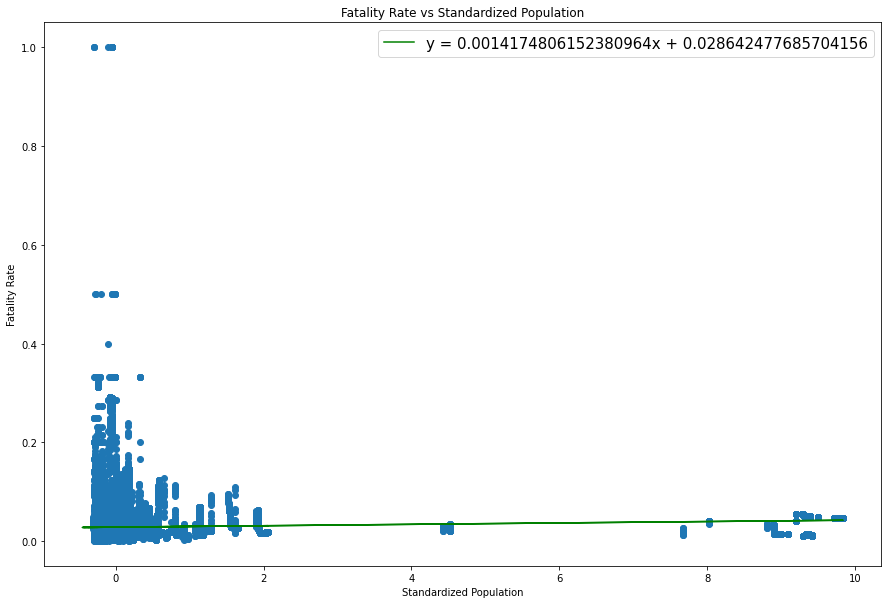

```python
# Set x and y values as standardized_population and fatality_rate respecgively.
x = df.standardized_population
y = df.fatality_rate

# Set figure, title, and axis labels.
plt.figure(figsize=(15,10))
plt.title("Fatality Rate vs Standardized Population")
plt.xlabel("Standardized Population")
plt.ylabel("Fatality Rate")

# Create scatter plot.
plt.scatter(x,y)

# Ignoring nan values, create linear regression for scatter plot.
idx = np.isfinite(x) & np.isfinite(y)
m, b = np.polyfit(x[idx], y[idx], 1)
plt.plot(x, b + m * x, '-g', label = "y = " + str(m) + "x + " + str(b))

# Show legend and plot.
plt.legend(loc = "upper right",prop={'size': 15})
plt.show()
```

Looking at the regression line, the global average, for a country with an average population (when standardized population is 0), has a fatality rate of 0.0286 deaths per confirmed case. And fatality rates increase by 0.0014 for every 1 standard unit of population (i.e. global fatality rate is 0.03, etc.)

```python
print("Global fatality rate: " + str(b) + " deaths per confirmed case.")
```

```
Global fatality rate: 0.028642477685704156 deaths per confirmed case.
```

Now, we can use compare this value with Indonesia's fatality ratio.

First, we plot Indonesia's total_deaths to total_cases over the whole time period in the dataset, and create a linear regression. The linear regression then yields the ratio of confirmed deaths to confirmed case as the regression line's gradient. We can then compare this value with the global fatality rate to determine Indonesia's fatality rate compared to the global average standardized by all countries' population.

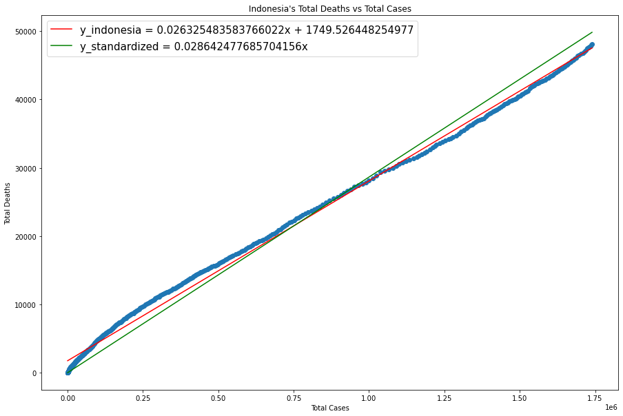

```python
# Set x and y values as standardized_population and fatality_rate respecgively.
x = df_indo.total_cases
y = df_indo.total_deaths

# Set figure, title, and axis labels.
plt.figure(figsize=(15,10))
plt.title("Indonesia's Total Deaths vs Total Cases")
plt.xlabel("Total Cases")
plt.ylabel("Total Deaths")
plt.scatter(x,y)

# Ignoring nan values, create linear regression for scatter plot.
idx = np.isfinite(x) & np.isfinite(y)
m_indo, b_indo = np.polyfit(x[idx], y[idx], 1)
plt.plot(x, b_indo + m_indo * x, '-r', label = "y_indonesia = " + str(m_indo) + "x + " + str(b_indo))
plt.plot(x, b * x, '-g', label = "y_standardized = " + str(b) + "x")

# Show legend and plot.
plt.legend(loc = "upper left",prop={'size': 15})
plt.show()
```

```python
print("Global fatality rate: " + str(b) + " deaths per confirmed case.")
print("Indonesia's fatality rate: " + str(m_indo) + " deaths per confirmed case.")
print("Difference: " + str(m_indo - b) + " deaths per confirmed case in Indonesia vs the World.")
```

```
Global fatality rate: 0.028642477685704156 deaths per confirmed case.
Indonesia's fatality rate: 0.026325483583766022 deaths per confirmed case.
Difference: -0.0023169941019381343 deaths per confirmed case in Indonesia vs the World.
```

Indonesia is below the global average for fatality rates in confirmed Covid-19 cases by 0.00231 deaths per confirmed case, adjusted by world population.

## Conclusion

### How well did Indonesia compare with other countries in terms of their Covid-19 handling?

Our analysis of the total confirmed cases, deaths, and vaccinations adjusted by the population, and time across all countries and time have indicated that Indonesia has below-average covid-19 cases based on population. However, the country falls short in vaccination rates and high fatality rate among covid-19 cases, compared with the global average. However, when the analysis on the fatality rates was improved by standardizing the population of countries worldwide, it was found that Indonesia's fatality rate is lower than the global average.

**Therefore, based on our analysis of this dataset, Indonesia has done a great job at handling the spread and fatality of Covid-19, despite critics claiming otherwise and being one of the most populated countries on earth. We can also conclude this: Numbers don't lie.**

Although numbers don't lie, people do, or the dataset was just simply incomplete. Due to the pandemic, the government have imposed many semi-lockdowns and other efforts to reduce the spread of the virus. Even so, media outlets still report soaring Covid-19 spread in Indonesia amid open international borders bringing in positive covid-19 travelers and open city borders allowing free travel of possibly covid-confirmed citizens. Moreover, misrepresentation of Covid-19 data and other factors may affect the numbers reported by the government. Other variables such as the human development index, hospital records, and bias from government and non-government data could be taken into account to improve the finding's accuracy.

Learn more about Indonesia's pandemic efforts [here](https://www.channelnewsasia.com/news/asia/indonesia-prepares-for-spike-covid-19-cases-after-idul-fitri-14826858).

Here are links to the topics mentioned throughout the project:

- [Pandas dataframe](https://www.google.com/search?client=safari&rls=en&q=pandas+dataframe+formatting&ie=UTF-8&oe=UTF-8)
- [Matlab 2d-line plots](https://www.mathworks.com/help/matlab/creating_plots/using-high-level-plotting-functions.html?requestedDomain=)
- [Numpy polyfit](https://blog.finxter.com/np-polyfit/)
- [SciKitLearn LinearRegression](https://stackabuse.com/linear-regression-in-python-with-scikit-learn/)
- [Pyplot scatter](https://www.tutorialspoint.com/matplotlib/matplotlib_scatter_plot.htm)
- [Seaborn violinplot](https://stackabuse.com/seaborn-violin-plot-tutorial-and-examples/)
- [Standardized test](https://www.statisticshowto.com/probability-and-statistics/hypothesis-testing/standardized-test-statistic/)
- [Hypothesis test](https://www.statisticshowto.com/probability-and-statistics/hypothesis-testing/)
- [Interpreting violin plots](https://mode.com/blog/violin-plot-examples/)
- [Pandas aggregate functions](https://cmdlinetips.com/2019/10/pandas-groupby-13-functions-to-aggregate/)